# Critical Materials Crossroads Engine: knowledge base

NSF Regional Innovation Engines, Cohort 2. Technology profile v1. Draft, in progress

**NSF Critical Materials Crossroads Engine in the Kansas City Region**, led by University of Missouri-Kansas City. NSF award 2532489, start August 2026. Search window for papers and patents: from August 2021 (five years before the award) onward.

## At a glance

| Measure | Value |
| --- | --- |
| People named by NSF or the Engine’s site | 17 |
| of them active researchers (>= 5 works since window start) | 1 |
| Team members who are inventors (2021-2025 grants, in the region) | 2 |
| Partners (site list + team members’ organisations) | 276 |
| Knowledge-producer partners (universities, labs, institutes) | 22 |
| Partner papers in the Engine’s topics | 1143 |
| of them with an in-region partner | 247 |
| Regional patents in the technology profile (2021-2025 grants) | 19 |
| Location quotient of the technology profile (patents) | 0.77 |
| Share of regional technology patents owned by partners | 0.0% |

## Economic base

| NAICS | Industry | Employment in region | Establishments | Share of US employment | Employment LQ |
| --- | --- | --- | --- | --- | --- |
| 331 | Primary metal manufacturing | 383 | 12 | 0.1% | 0.15 |
| 325 | Chemical manufacturing | 7,839 | 107 | 0.9% | 1.18 |
| 3359 | Other electrical equipment and components (incl. batteries) | 479 | 5 | 0.3% | 0.43 |

Industries related to the Engine’s technology (chosen from the NSF abstract, see `data/manual/engine_naics.csv`). County Business Patterns 2023; LQ = the industry’s share of regional employment relative to its share of US employment (1 = US average). Region: 14 of 14.

## Technology profile

Version 1. The profile has 3 statements. Item 1 comes from the grant title, the rest from the technical part of the NSF abstract. Each statement is mapped to one OpenAlex topic and to CPC codes.

| # | Source | Statement | OpenAlex topic | Subfield | CPC |
| --- | --- | --- | --- | --- | --- |
| 1 | title | Critical materials production and refining | Extraction and Separation Processes | Metals and Alloys | C22B |
| 2 | abstract | Domestic metal refining at industrial scale | Metallurgical Processes and Thermodynamics | Metals and Alloys | C22B; C25C |
| 3 | abstract | Materials processing scale-up with continuous flow processing, in-line monitoring and data-driven process control | Innovative Microfluidic and Catalytic Techniques Innovation | Fluid Flow and Transfer Processes | B01J19; G05B13 |

## People

| Role | People |
| --- | --- |
| organizer | 13 |
| researcher | 4 |

| Name | Role | On NSF award | Title | Organisation | Works since window (in Engine topics) | h-index | Patents 2021-25 (in Engine profile) | Site | OpenAlex |
| --- | --- | --- | --- | --- | --- | --- | --- | --- | --- |
| Ben Ketter | researcher |  | Director of Engineering | Critical Materials Crossroads | - | - |  | [page](https://www.crit-mat.org/our-team/) |  |
| Mostafizur Rahman | researcher | Co-PI | Chief Technology Officer | Critical Materials Crossroads | - | - | 1 (0) | [page](https://www.crit-mat.org/our-team/) |  |
| Nathan Mauck | researcher | Co-PI | Chief Financial Officer | Critical Materials Crossroads | 12 (0) | 12 |  | [page](https://www.crit-mat.org/our-team/) | [profile](https://openalex.org/A5043577837) |
| Zach Goss | researcher |  | Scientist | Critical Materials Crossroads | - | - |  | [page](https://www.crit-mat.org/our-team/) |  |
| Angela Cottrell | organizer |  | Chief Operating Officer | Critical Materials Crossroads | - | - |  | [page](https://www.crit-mat.org/our-team/) |  |
| Anthony Caruso | organizer | PI | Chief Executive Officer | Critical Materials Crossroads | 0 | 1 | 3 (0) | [page](https://www.crit-mat.org/our-team/) | [profile](https://openalex.org/A5103363792) |
| Anthony Weiss | organizer |  | Chief Workforce Officer | Critical Materials Crossroads | - | - |  | [page](https://www.crit-mat.org/our-team/) |  |
| Ashlynn Horras | organizer |  | Director of Capital Investments | Critical Materials Crossroads | - | - |  | [page](https://www.crit-mat.org/our-team/) |  |
| Darius Watson | organizer | Co-PI | Chief Partnerships Officer | Critical Materials Crossroads | - | - |  | [page](https://www.crit-mat.org/our-team/) |  |
| Eric Anderson | organizer |  | Chief Intellectual Property Officer | Critical Materials Crossroads | - | - |  | [page](https://www.crit-mat.org/our-team/) |  |
| Janelle Sjue | organizer |  | Director of Grants Strategy and Subcontracts | Critical Materials Crossroads | - | - |  | [page](https://www.crit-mat.org/our-team/) |  |
| Jeff Blackwood | organizer |  | Director of Technology Translation | Critical Materials Crossroads | - | - |  | [page](https://www.crit-mat.org/our-team/) |  |
| Katie Dixon | organizer |  | Director of Finance Strategy | Critical Materials Crossroads | - | - |  | [page](https://www.crit-mat.org/our-team/) |  |
| Lee Stadler | organizer |  | Collaboration Architect | Critical Materials Crossroads | - | - |  | [page](https://www.crit-mat.org/our-team/) |  |
| Maria Meyers | organizer | Co-PI | Chief Commercialization Officer | Critical Materials Crossroads | - | - |  | [page](https://www.crit-mat.org/our-team/) |  |
| Stacey Eisele | organizer |  | Director of Strategic Communications | Critical Materials Crossroads | - | - |  | [page](https://www.crit-mat.org/our-team/) |  |
| William Highsmith | organizer |  | Chief of Staff | Critical Materials Crossroads | - | - |  | [page](https://www.crit-mat.org/our-team/) |  |

Publication counts are shown only where the OpenAlex author matches both the name and the person’s current organisation. The OpenAlex link is given only for these reliable matches, and not for profiles flagged as possibly merging several namesakes. *Site* links to the page of the Engine’s website where the person is named. Click a number of works to see the list on the Publications page. *Patents*: US grants 2021-2025 with the person among the inventors (same last and first name, address in the Engine’s states); click the number for the list on the Patents page. In brackets: works in the Engine’s topics, patents with a CPC code in the Engine’s technology profile.

## Researchers at partner organisations

| # | Researcher | Partner | Works in the Engine’s topics | Citations | Years | Most cited of these works |
| --- | --- | --- | --- | --- | --- | --- |
| 1 | [Ronald J. O’Malley](https://openalex.org/A5018441993) | Missouri University of Science and Technology | 48 | 324 | 2021-2026 | [In Situ and Real-Time Mold Flux Analysis Using a High-Tem…](https://openalex.org/W4318259773) |
| 2 | [Mark E. Schlesinger](https://openalex.org/A5039018099) | Missouri University of Science and Technology | 23 | 62 | 2021-2024 | [Overview](https://openalex.org/W4200054877) |
| 3 | [Jie Huang](https://openalex.org/A5028758562) | Missouri University of Science and Technology | 22 | 181 | 2021-2026 | [In Situ and Real-Time Mold Flux Analysis Using a High-Tem…](https://openalex.org/W4318259773) |
| 4 | [Mario F. Buchely](https://openalex.org/A5073297038) | Missouri University of Science and Technology | 22 | 66 | 2021-2026 | [Implementation of Experimental Static Recrystallization o…](https://openalex.org/W4367053055) |
| 5 | [Michael S. Moats](https://openalex.org/A5042449090) | Missouri University of Science and Technology | 21 | 196 | 2021-2026 | [Global tellurium supply potential from electrolytic coppe…](https://openalex.org/W4281672554) |
| 6 | [Simon Naumovich Lekakh](https://openalex.org/A5070805212) | Missouri University of Science and Technology | 19 | 64 | 2022-2026 | [Effect of Cu Additions on Scale Structure and Descaling E…](https://openalex.org/W4291168069) |
| 7 | [Rex E. Gerald](https://openalex.org/A5075205593) | Missouri University of Science and Technology | 18 | 166 | 2021-2025 | [In Situ and Real-Time Mold Flux Analysis Using a High-Tem…](https://openalex.org/W4318259773) |
| 8 | [Lana Alagha](https://openalex.org/A5052202260) | Missouri University of Science and Technology | 18 | 113 | 2023-2026 | [Progress, challenges, and perspectives of critical elemen…](https://openalex.org/W4401023056) |
| 9 | [Ronald J. O’Malley](https://openalex.org/A5008372753) | Missouri University of Science and Technology | 17 | 33 | 2022-2026 | [A Lab-Scale Mold Simulator Employing an Optical-Fiber-Ins…](https://openalex.org/W4399011003) |
| 10 | [Todd P. Sander](https://openalex.org/A5071957131) | Missouri University of Science and Technology | 15 | 70 | 2023-2026 | [In Situ and Real-Time Mold Flux Analysis Using a High-Tem…](https://openalex.org/W4318259773) |
| 11 | [Farhan Mumtaz](https://openalex.org/A5031842233) | Missouri University of Science and Technology | 14 | 69 | 2022-2026 | [Temperature Monitoring in the Refractory Lining of a Cont…](https://openalex.org/W4312432409) |
| 12 | [Jeffrey D. Smith](https://openalex.org/A5004517322) | Missouri University of Science and Technology | 13 | 130 | 2022-2025 | [In Situ and Real-Time Mold Flux Analysis Using a High-Tem…](https://openalex.org/W4318259773) |
| 13 | [Hanok Tekle](https://openalex.org/A5010093435) | Missouri University of Science and Technology | 12 | 95 | 2022-2026 | [In Situ and Real-Time Mold Flux Analysis Using a High-Tem…](https://openalex.org/W4318259773) |
| 14 | [Laura N. Bartlett](https://openalex.org/A5071856782) | Missouri University of Science and Technology | 11 | 85 | 2021-2026 | [Temperature Monitoring in the Refractory Lining of a Cont…](https://openalex.org/W4312432409) |
| 15 | [Viraj Ashok Athavale](https://openalex.org/A5040581912) | Missouri University of Science and Technology | 11 | 19 | 2021-2025 | [Growth Kinetics and Development of the Solid–Liquid Inter…](https://openalex.org/W4400533110) |

The grant names mostly managers; the technology is often developed at the partner universities and labs. These are the authors with the most works in the Engine’s OpenAlex topics written at a knowledge-producer partner in the Engine’s states, since the window start (at least 3 works; top 15). The list depends on the technology profile version. OpenAlex sometimes merges namesakes into one author: check the profile before relying on a name.

## Partners

| Organisation class | Partners |
| --- | --- |
| company | 136 |
| government | 40 |
| intermediary | 31 |
| investor | 30 |
| university | 14 |
| philanthropy | 8 |
| national_lab | 6 |
| k12_education | 5 |
| community_college | 4 |
| research_institute | 2 |

Partner list on the site: *Complete directory by category (about 290 entries with repeats)*.

| Partner | Class | State | OpenAlex works since window (all topics) |
| --- | --- | --- | --- |
| Pacific Northwest National Laboratory | national_lab | Washington | 1362797 |
| Michigan State University | university | Michigan | 154196 |
| Lawrence Livermore National Laboratory | national_lab | California | 35861 |
| University of Missouri | university | Missouri | 33735 |
| Argonne National Laboratory | national_lab | Illinois | 28153 |
| West Virginia University | university | West Virginia | 27118 |
| University of Kansas | university | Kansas | 24782 |
| Kansas State University | university |  | 22319 |
| Colorado School of Mines | university | Colorado | 17985 |
| National Laboratory of the Rockies | national_lab | Colorado | 17683 |
| University of Missouri-Kansas City | university | Missouri | 11443 |
| Missouri University of Science and Technology | university | Missouri | 7501 |
| Missouri State University | university | Missouri | 2969 |
| Wichita State University | university |  | 2969 |
| University of Missouri-St. Louis | university | Missouri | 2910 |
| Ames National Laboratory | national_lab | Iowa | 2230 |
| Pittsburg State University | university | Kansas | 1127 |
| Lincoln University - Missouri | university | Missouri | 316 |
| PM NSWC Carderock (NSWCCD) | research_institute | Maryland | 281 |
| Missouri Western State University | university | Missouri | 246 |
| Kansas City National Security Campus | national_lab | Missouri | 184 |
| MRI Global | research_institute |  | NA |

## Science base: partner papers in the Engine’s topics

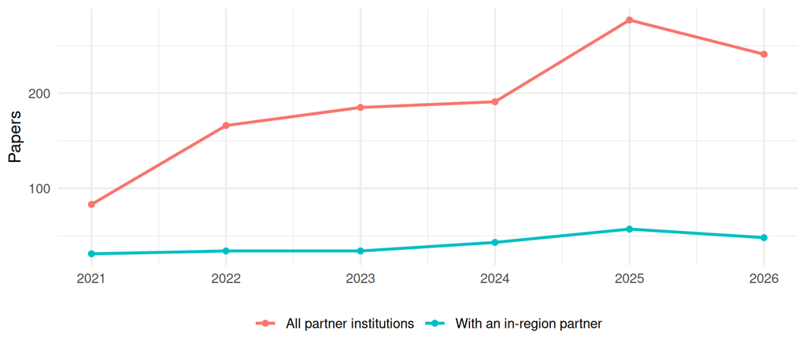

| Partner | Papers in topics |
| --- | --- |
| Argonne National Laboratory | 301 |
| Colorado School of Mines | 230 |
| Missouri University of Science and Technology | 186 |
| National Laboratory of the Rockies | 130 |
| Lawrence Livermore National Laboratory | 107 |
| West Virginia University | 73 |
| Ames National Laboratory | 62 |
| Michigan State University | 28 |
| University of Missouri | 27 |
| University of Kansas | 19 |

## Technology base: patents

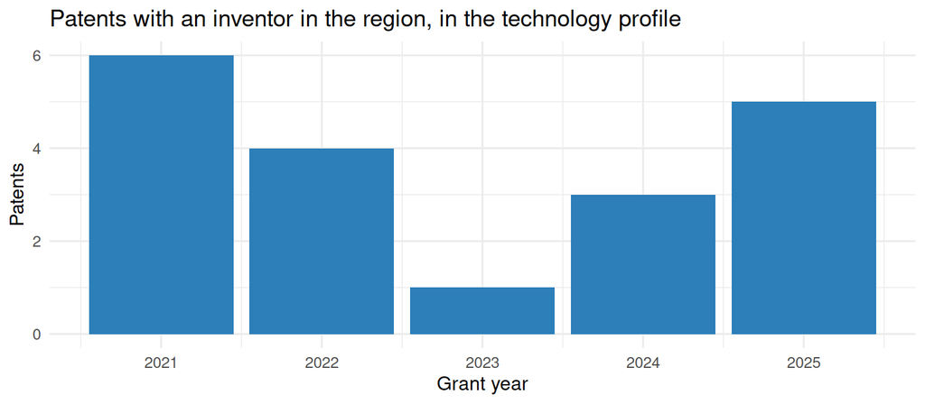

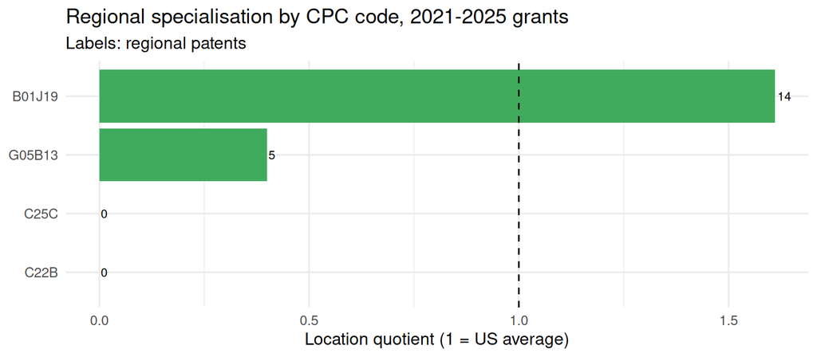

| Assignee | Regional patents in profile |
| --- | --- |
| Honeywell Federal Manufacturing & Technologies, LLC | 3 |
| MILTON ROY, LLC | 2 |
| Micron Pure, LLC | 2 |
| Refining Technology Solutions, LLC | 2 |
| Rockwell Automation Technologies, Inc. | 2 |
| Synexis LLC | 2 |
| Ion Inject Technology LLC | 1 |
| JOHNSON CONTROLS LIGHT COMMERCIAL IP GMBH | 1 |
| Johnson Controls Tyco IP Holdings LLP | 1 |
| The Boeing Company | 1 |

Partner-owned patents invented in the region: 64, of which 0 (0.0%) fall in the Engine’s technology profile.

## Competition

With 19 patents in the technology profile (2021-2025 grants), the Engine’s region would rank **37** among US states; its specialisation (LQ) is 0.774.

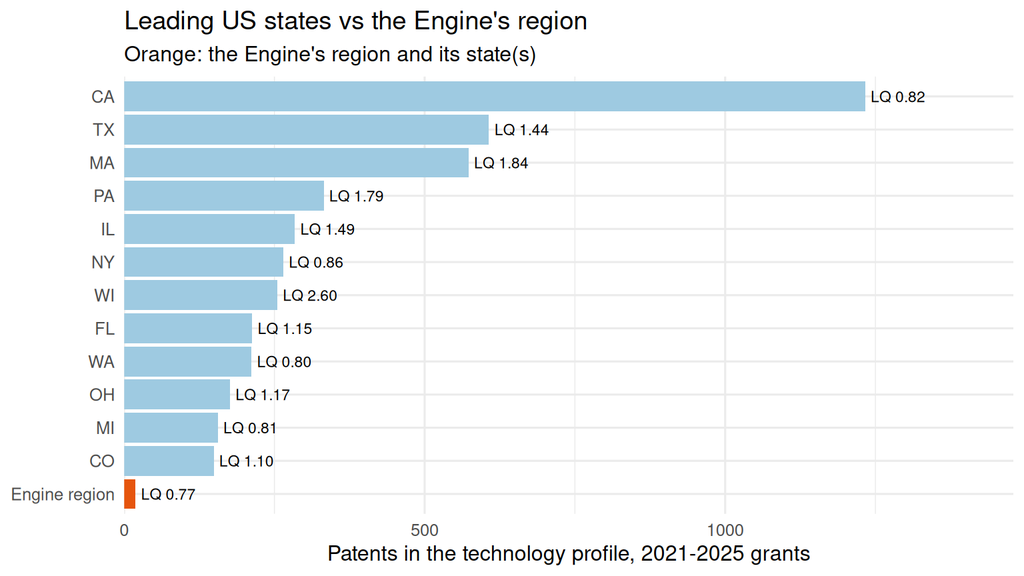

| Country | Share of US patents in profile | Share of world papers in topics |
| --- | --- | --- |
| US | 51.9% | 7.1% |
| JP | 9.6% | 3.2% |
| CN | 7.7% | 33.0% |
| DE | 6.1% | 3.7% |
| CA | 4.2% | 2.1% |
| KR | 4.2% | 2.4% |
| GB | 3.1% | 2.7% |
| FR | 2.7% | 2.5% |
| IN | 2.5% | 4.1% |
| SA | 1.9% | NA |

Patents: inventor countries on US grants in the profile (a patent counts for every country of its inventors). Papers: author countries of OpenAlex works in the Engine’s topics since the window start.

## Data and limitations

- People: PIs and Co-PIs from the NSF Award API; leadership listed on the Engine’s website. Roles come from titles and organisations, revised with OpenAlex evidence.
- Partners: as listed on the Engine’s website, plus organisations of team members. Some Engines publish partner logos without names.
- Region: the Engine’s counties where the list is known (NEO-SMART: 18 Northeast Ohio counties; STELLAR: 11 counties from the NSF abstract), otherwise its states (state-level proxy).
- Technology profile: v1 (switch versions in the header). Partner papers and regional patents depend on it: v1 uses mostly CPC subclasses, the v3.1 core uses CPC main groups, which are narrower, so it counts fewer patents and the LQ of a small region rests on few patents.
- Papers: OpenAlex; partner papers are restricted to the Engine’s OpenAlex topics.
- Patents: USPTO grants 2021-2025; inventor locations from PatentsView; pre-grant publications are not included.